# Computer Test - Example responses

STAT5003 Semester 1, 2022

9th April, 2022

### Question 1

Construct and analyze a binary classifier from a simulated dataset using your SID and the `mlbench` package.

1. **[4 marks]** Simulate a single dataset of `n = 500` observations completing the code below replacing `<insert SID here>` with your SID respectively and changing the `eval = FALSE` setting to `eval = TRUE` in the `R` code chunk. Then, inspect the `q2.dat` using the `head` command and verify the dimension of the `data.frame` and that there are 2 numeric features and a single factor variable of class labels. **Note**: *You should explicitly verify the data type is numeric or factor or inspect the class of each column*.

```r
library(mlbench)
set.seed(5003)
simulated.data <- mlbench.2dnormals(n = 500, sd = 2)
q2.dat <- as.data.frame(simulated.data)
head(q2.dat)
```

```
##          x.1        x.2 classes
## 1  2.3110637 -2.4235455       1
## 2 -2.1471013 -6.8373623       2
## 3 -3.4813172 -1.2873004       2
## 4 -1.4097769  2.1890729       2
## 5  0.1110965  0.7407209       1
## 6  0.1862293  2.3522997       1
```

```r
dim(q2.dat)
```

```
## [1] 500   3
```

```r
# Any of the below are acceptable
lapply(q2.dat, class)
```

```
## $x.1
## [1] "numeric"
##
## $x.2
## [1] "numeric"
##
## $classes
## [1] "factor"
```

```r
str(q2.dat)
```

```
## 'data.frame':    500 obs. of  3 variables:
##  $ x.1    : num  2.311 -2.147 -3.481 -1.41 0.111 ...
##  $ x.2    : num  -2.424 -6.837 -1.287 2.189 0.741 ...
##  $ classes: Factor w/ 2 levels "1","2": 1 2 2 2 1 1 1 1 2 1 ...
```

2. **[6 marks]** Split the simulated data into 75% training and 25% test data set using `caret::createDataPartition` or otherwise. Then fit a **logistic** regression model to explain the classes response using the two features on the **training data**. Predict the classes on the **test data** using your fitted logistic regression model and the threshold for classification using the esimated probability of being in the positive class at 0.5. Compute the accuracy on the test set in this situation.

```r
train.ind <- caret::createDataPartition(q2.dat[["classes"]], p = 0.75)[[1]]
training.data <- q2.dat[train.ind, ]
test.data <- q2.dat[-train.ind, ]
trained.model <- glm(classes ~ ., data = training.data, family = binomial(link = "logit"))
predicted.classes <- ifelse(predict(trained.model, newdata = test.data) > 0.5, 2, 1)
accuracy <- mean(predicted.classes == test.data[["classes"]])
accuracy
```

```
## [1] 0.8225806
```

3. Create a scatter plot of the data in the **test** set and colour each point by its true class label. Draw the linear decision boundary generated by the **logistic** regression model fitted above. Comment on how the accuracy computed on the test set in part c. relates to your plot and decision boundary.

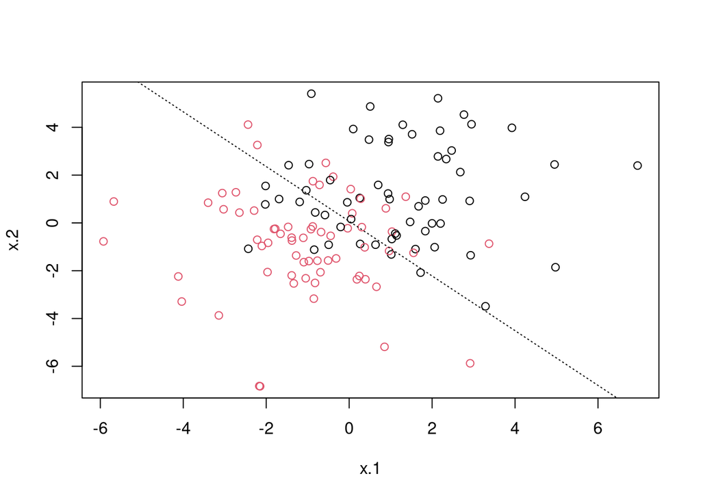

```r
plot(x.2 ~ x.1, data = test.data, col = classes)
betas <- coef(trained.model)
abline(a = -betas[1]/betas[3], b = -betas[2]/betas[3], lty = "dotted")
```

The model will classify points in the bottom left of the plot (below the boundary) as being in the positive class and points in the top right (above the boundary) as the negative class. These classifications are correct 82.2580645% of the time.

### Question 2

```r
messy.duration <- readRDS('messy-s1-22-q2.rds')
clean.duration <- readRDS('clean-s1-22-q2.rds')
```

Suppose only the messy dataset was only available initially and requires cleaning by removing the negative and missing (`NA`) values. The goal here is the clean the messy dataset and then provide an analysis of the stability of the bandwidths in the `density` algorithm.

1. **[4 marks]** Some geyser eruptions were recorded incorrectly with a negative duration or were coded as missing (coded as `NA`). Using relevant `R` code, verify that `messy.duration` is a `numeric` vector with `341` observations. Also count the number of observations that are negative and the number that are coded as missing (i.e. `NA`).

```r
length(messy.duration)
```

```
## [1] 341
```

```r
n.missing <- sum(is.na(messy.duration))
n.negative <- sum(messy.duration < 0, na.rm = TRUE)
c(`n missing` = n.missing, `n negative` = n.negative)
```

```
##  n missing n negative
##         22         20
```

```r
my.cleaned.duration <- messy.duration[!is.na(messy.duration) & messy.duration > 0]
identical(my.cleaned.duration, clean.duration)
```

```
## [1] TRUE
```

From this point onwards, answer the questions using only the `clean.duration` dataset.

3. **[6 marks]** Produce a histogram and kernel density estimate of the cleaned data on the *same plot*. Using either the base `R` plotting commands (e.g. `hist`) or using the `ggplot2` comments are fine, no need to use both. Also no need to do bandwidth selection in this question and any default bandwidths are fine.

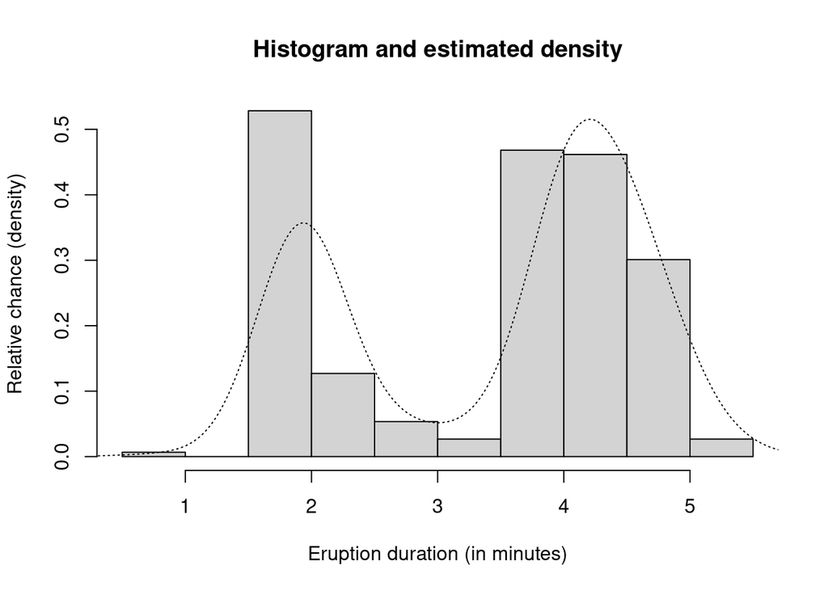

```r
hist(clean.duration, xlab = "Eruption duration (in minutes)", ylab = "Relative chance (density)",
     prob = TRUE, main = "Histogram and estimated density")
lines(density(clean.duration), col = 1, lty = "dotted")
```

```r
set.seed(5003)
B <- 299L
bootstrapped.indices <- replicate(B, sample.int(B, replace = TRUE, size = B), simplify = FALSE)
bootstrapped.geyser <- lapply(bootstrapped.indices, \(x) clean.duration[x])
```

5. **[3 marks]** Using your bootstrapped geyser data above, analyze how variable the default bandwidth estimator is on this bootstrapped data. Visualize your results using a boxplot (again using either the base `boxplot` command or `ggplot2` suite are fine, no need to do both). **Hint**: This can be done by extracting the `bw` element of the return output of `density` or by calling the function `bw.nrd0` instead.

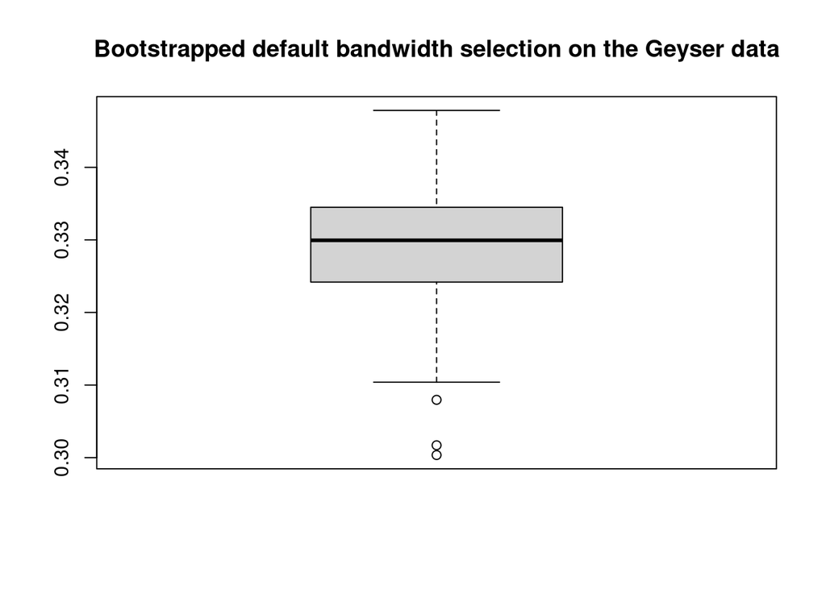

```r
default.bandwidths <- vapply(bootstrapped.geyser, bw.nrd0, numeric(1L))
boxplot(default.bandwidths, main = "Bootstrapped default bandwidth selection on the Geyser data")
```

The distribution looks bimodal with two peaks, consider now an alternative way to estimate the density as the mixture of two normal densities. A mixture of two normal densities is a model which is essentially a weighted combination of two standard Gaussian densities, one centered at the first peak and another at a second peak. The weights here denote the chance of beloning to each Gaussian. The associated joint log likelihood of such a model is defined below.
$$\mathcal L(\boldsymbol{\theta}| \mathcal X) = \begin{cases} \sum_{i
= 1}^n \log \left(p g(x_i; \mu_1,\sigma_1) + (1 - p)g( x_i; \mu_2,
\sigma_2 )\right),& \text{ if } 0 < p < 1 , \sigma_1 > 0
\text{ and } \sigma_2 > 0;\\
-\infty, & \text{otherwise}.\end{cases}$$
where $g(x; \mu, \sigma)$ is the normal density with mean $\mu$ and standard deviation of $\sigma$ and $\mathcal X = \left\{ x_1, x_2,\ldots, x_n\right\}$ denotes all the sample data. **Hint**: The function `dnorm` is useful here and the mean and standard deviation can be set with the `mean` and `sd` arguments.

```r
negativeLikelihood <- function(p, mu1, s1, mu2, s2) {
  if (p > 1 || p < 0 || s1 <= 0 || s2 <= 0) return(Inf)
  -sum(log(p * dnorm(clean.duration, mean = mu1, sd = s1) + (1 - p) * dnorm(clean.duration, mean = mu2, sd = s2)))
}
```

7. **[2 marks]** Compute the MLE of $\boldsymbol{\theta}$ using `stats4::mle`. **Hint**: The starting point of the algorithm is required with the `start` argument list, choose an appropriate starting point based off the histogram or density estimate computed in part c. e.g. the mean of the two components could be started at the highest peaks in the earlier plot in c.

```r
mle <- stats4::mle(negativeLikelihood, start = list(p = 0.5, mu1 = 2, s1 = 1, mu2 = 4, s2 = 1))
mle
```

```
##
## Call:
## stats4::mle(minuslogl = negativeLikelihood, start = list(p = 0.5,
##     mu1 = 2, s1 = 1, mu2 = 4, s2 = 1))
##
## Coefficients:
##         p       mu1        s1       mu2        s2
## 0.3395289 1.9504756 0.2282124 4.2372580 0.4313232
```

8. **[2 marks]** Produce a **single** plot of the histogram, density estimate computed in part c. and the estimated mixture of two Gaussians at the MLE and comment which seems superior, the MLE using a Gaussian mixture or the density estimator? **Hint** The density of a mixture of two Gaussians, $f$ is defined below.
   $$f(x; p, \mu_1, \sigma_1, \mu_2, \sigma_2) = pg( x; \mu_1, \sigma_1) + (1
   - p)g( x; \mu_2,\sigma_2), \qquad \text{ where } 0 < p < 1 \text{
   and } \sigma_1 > 0 \text{ and } \sigma_2 > 0.$$
   Again, the function $g(x; \mu, \sigma)$ denotes the Gaussian density with mean $\mu$ and standard deviation $\sigma$ and the `R` function `dnorm` is useful here.

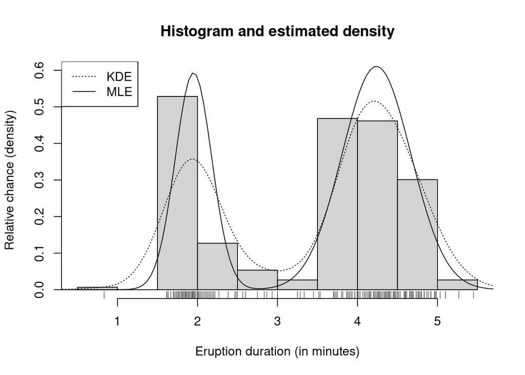

```r
hist(clean.duration, xlab = "Eruption duration (in minutes)", ylab = "Relative chance (density)",
     prob = TRUE, main = "Histogram and estimated density", ylim = c(0, 0.6))
lines(density(clean.duration), col = 1, lty = "dotted")
x <- seq(from = 0, to = 6, length = 128)
p <- mle@coef[["p"]]
mu1 <- mle@coef[["mu1"]]
s1 <- mle@coef[["s1"]]
mu2 <- mle@coef[["mu2"]]
s2 <- mle@coef[["s2"]]
y <- p * dnorm(x, mean = mu1, sd = s1) + (1 - p) * dnorm(x, mean = mu2, sd = s2)
lines(x, y)
legend("topleft", legend = c("KDE", "MLE"), lty = c("dotted", "solid"))
rug(clean.duration)
```

The MLE of the Gaussian mixture above looks superior as the KDE appears oversmoothed while the MLE covers the high density areas more appropriately